# WeRateDogs act report¶

### intro

In Data wrangling, 3 steps were performed to gather, assess and clean the datasets that contain tweets on people’s dogs with the rating,image and comments, etc was there. The data is then explorex and analyzed. For data wrangling process, please refer to wrangle_act file for steps and codes.

## insights

- first insight is the correlation between the retweet counts and the favorite counts and it was calcuated r=0.863688 on Pearson so it was a postive correlation and below you can see the graph representing this positive correlation so as the count of favorites increases the tweets increases too

```python
import pandas as pd
import numpy as np
import requests
from PIL import Image
from io import BytesIO
import tweepy
import json
import os
import seaborn as sns
import matplotlib.pyplot as plt
%matplotlib inline
%config Inlinebackend.figure_format='retina'
sns.set_style("dark")
```

```python
df_master=pd.read_csv('twitter_archive_master.csv')
```

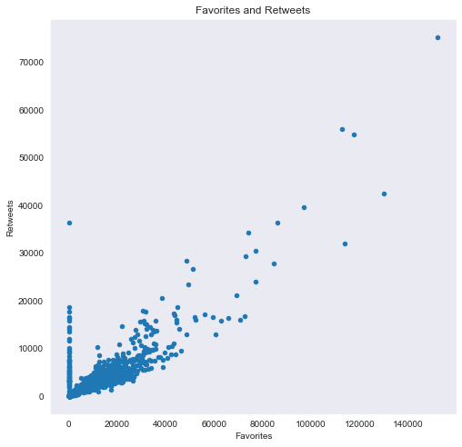

```python
m=df_master.plot(x='favorite_count',y='retweet_count',kind='scatter',figsize=(8,8))
plt.title("Favorites and Retweets")
plt.xlabel('Favorites')
plt.ylabel('Retweets')
fig = m.get_figure()
```

### The only other coefficient worth mentioning is the between prediction1_rate and prediction3_rate which is -0.709194, demonstrating a negative semi-strong relationship. This is probably a result because p3_conf confidence score is affected by the results of the first prediction in the neural network. The more confident the result of the first image, the less likely the following images would accurately guess the breed of dog.

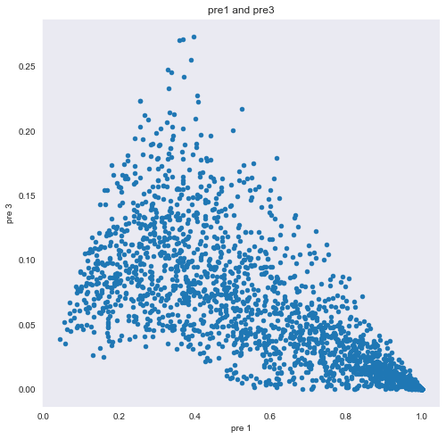

```python
m=df_master.plot(x='prediction1_rate',y='prediction3_rate',kind='scatter',figsize=(8,8))
plt.title("pre1 and pre3")
plt.xlabel('pre 1')
plt.ylabel('pre 3')
fig = m.get_figure()
fig.savefig('scatterplot4.png');
```

- second insight is the development of the trend over time whic icludes the rate of the retweet count average and the rate of favorite count average and what i noticed here is that the average rate of the favorite counts boomed starting from 2017 but i had a steady rising base over the previous years though

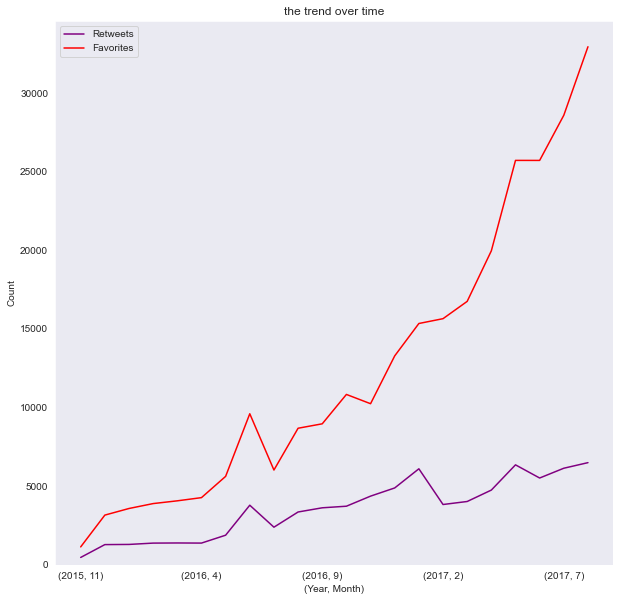

```python
df_master["timestamp"]=pd.to_datetime(df_master["timestamp"])
plt.subplots(1, sharex=True)
df_master.retweet_count.groupby([df_master["timestamp"].dt.year, df_master["timestamp"].dt.month]).mean().plot(kind='line',figsize=(10,10),color='purple')
df_master.favorite_count.groupby([df_master["timestamp"].dt.year, df_master["timestamp"].dt.month]).mean().plot(kind='line',figsize=(10,10),color='red').set_ylim(0, )
plt.title('the trend over time')
plt.ylabel('Count')
plt.xlabel('(Year, Month)')
plt.legend(('Retweets', 'Favorites'));
```

- third insight was to find out which dog breed was the most popular and the result was golden retriever in the top followed by lbrador retriever and slightly behind him in the third place is the pembroke

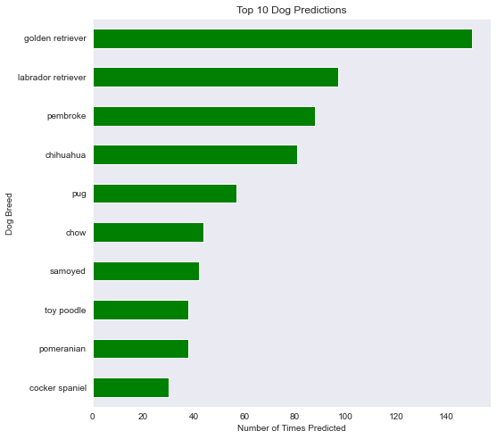

```python
ii=df_master['prediction1'].value_counts()[9::-1].plot(kind='barh',color='green',figsize=(8,8))
plt.title('Top 10 Dog Predictions')
plt.xlabel('Number of Times Predicted')
plt.ylabel('Dog Breed')
plt.fontsize = 12;
```

[figure not shown]

-isn't he cute ?

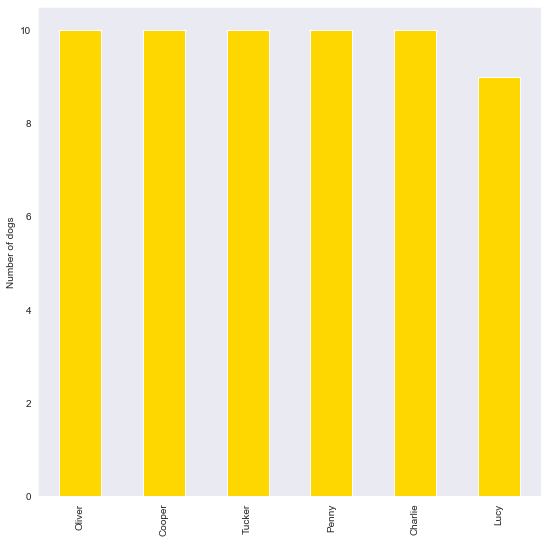

```python
lolo=df_master.name.value_counts()[0:6].plot(kind='bar',figsize=(9,9),color='gold')
plt.ylabel('Number of dogs');
```

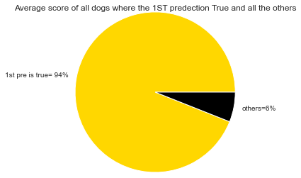

```python
#pie chart between score of all the dogs where the first prediction is true  and the all of the others
plt.pie([94,6],labels=['1st pre is true= 94%','others=6%'],colors=['gold','black'],radius=1.3)
plt.title('Average score of all dogs where the 1ST predection True and all the others');
plt.savefig('averagescore')
```

## my last insight is a word cloud from the tweets

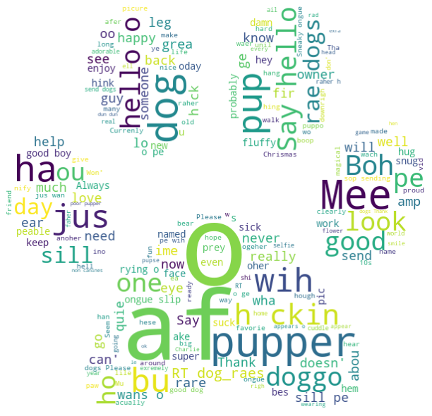

```python
# creating a list with all the words tweeted in our data frame
tweets = np.array(df_master.text)
cloud_list = []
for tweet in tweets:
    cloud_list.append(tweet.replace("\n",""))
#removing the most frequent words https and co which are in the url
new_set = {x.replace('https', '').replace('co','').replace('t','') for x in cloud_list}
# download a paw image to use ait as the cloud
mask = np.array(Image.open(requests.get('https://clipartix.com/wp-content/uploads/2016/06/Dog-bone-pink-print-dog-paw-print-transparent-background-paw-print-pink-clipart.jpg', stream=True).raw))
text = new_set
from wordcloud import WordCloud, STOPWORDS

def gen_wc(text, mask):
    word_cloud = WordCloud(width = 500, height = 500, background_color='white', mask=mask).generate(str(text))
    plt.figure(figsize=(10,8),facecolor = 'white', edgecolor='red')
    plt.imshow(word_cloud)
    plt.axis('off')
    plt.tight_layout(pad=0)
    plt.show()
gen_wc(text, mask)
```

#### that was all

```python
from IPython.display import HTML

HTML('''<script>
code_show=true;
function code_toggle() {
 if (code_show){
 $('div.input').hide();
 } else {
 $('div.input').show();
 }
 code_show = !code_show
}
$( document ).ready(code_toggle);
</script>
<form action="javascript:code_toggle()"><input type="submit" value="Click here to toggle on/off the raw code."></form>''')
```